# Practical Machine Learning: Final Project

joog2006

Sunday, October 25, 2015

## Summary

Data from the Weight Lifting Exercise experiment from the Human Activity Recognition (http://groupware.les.inf.puc-rio.br/har) site is used to predict the quality of a weight lifting rep. Correct lifts are classified as “A.” A random forest model is constructed with accurate out of sample predictions.

[figure not shown]

## Exploratory Analysis

Exploratory data analysis shows that the predictor data generally have low correlations with each other. This opens the door for linear estimation methods with only a minmal need for principal components analysis to reduce dimensionality.

#### Figure 1: Correlation plot of prediction variables

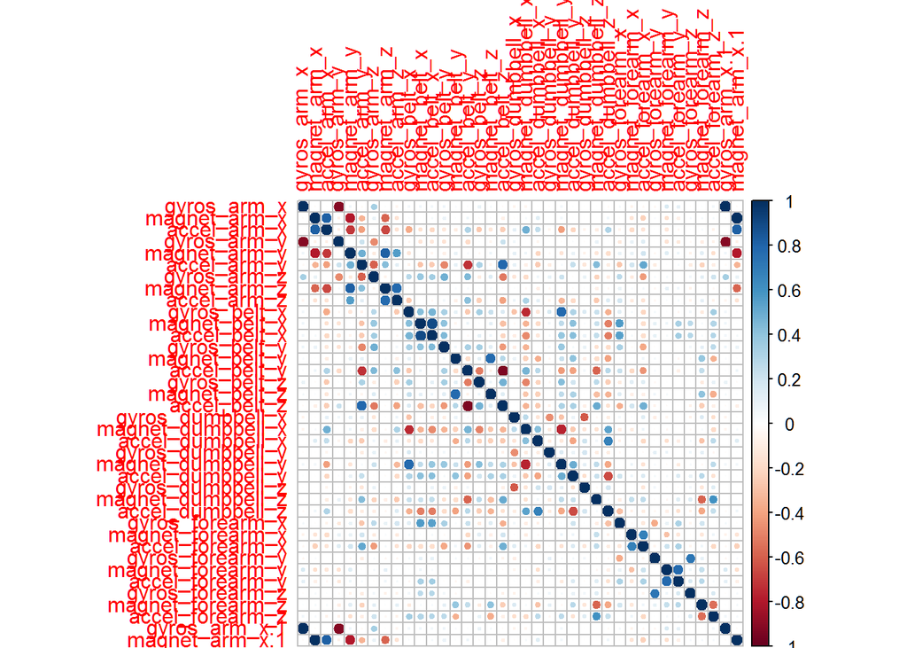

## Random Forest Model

A random forest model is constructed with all of the magnet, accelerameter, and gyroscopic values used as predictors for the random forest. Cross validation is used through the “trainControl” feature of the caret package. Five resamplings are conducted.

```r
rfModel$finalModel
```

```
##
## Call:
##  randomForest(x = x, y = y, mtry = param$mtry, proximity = TRUE,      allowParallel = TRUE)
##                Type of random forest: classification
##                      Number of trees: 500
## No. of variables tried at each split: 2
##
##         OOB estimate of  error rate: 1.29%
## Confusion matrix:
##      A    B    C    D    E class.error
## A 3896    4    0    6    0 0.002560164
## B   34 2603   21    0    0 0.020692250
## C    0   28 2368    0    0 0.011686144
## D    6    0   68 2176    2 0.033747780
## E    1    1    1    5 2517 0.003168317
```

An example of a tree from the random forest. ####Figure 2: Example of Tree from Random forest

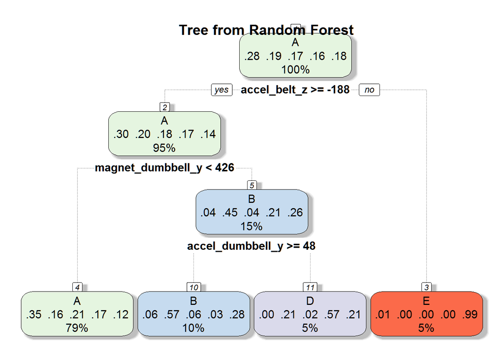

## Out of sample validation

#### Figure 3: Confusion Matrix for Random Forest Prediction of Test Data

```
## Confusion Matrix and Statistics
##
##           Reference
## Prediction    A    B    C    D    E
##          A 1672   15    2    0    0
##          B    1 1113   10    0    0
##          C    0   11 1013   23    3
##          D    0    0    1  941    3
##          E    1    0    0    0 1076
##
## Overall Statistics
##
##                Accuracy : 0.9881
##                  95% CI : (0.985, 0.9907)
##     No Information Rate : 0.2845
##     P-Value [Acc > NIR] : < 2.2e-16
##
##                   Kappa : 0.9849
##  Mcnemar's Test P-Value : NA
##
## Statistics by Class:
##
##                      Class: A Class: B Class: C Class: D Class: E
## Sensitivity            0.9988   0.9772   0.9873   0.9761   0.9945
## Specificity            0.9960   0.9977   0.9924   0.9992   0.9998
## Pos Pred Value         0.9899   0.9902   0.9648   0.9958   0.9991
## Neg Pred Value         0.9995   0.9945   0.9973   0.9953   0.9988
## Prevalence             0.2845   0.1935   0.1743   0.1638   0.1839
## Detection Rate         0.2841   0.1891   0.1721   0.1599   0.1828
## Detection Prevalence   0.2870   0.1910   0.1784   0.1606   0.1830
## Balanced Accuracy      0.9974   0.9874   0.9899   0.9877   0.9971
```

## Conclusion

The out of sample error rate and cross validation in creating the Random Forest imply that this model should perform very well in a real world test to identify rep performance giving sensor data. Moreover, the sensitivity and specificity rates for classifying “A” are very high, so distinguishing between correct and incorrect reps should be even stronger than precisely determining the type of error (classified B, C, D, E).